# How has commuting behaviour changed in Central London following the pandemic?

# Will working from home stick in the post-pandemic period? A brief study on travel behaviour in London’s financial districts.

This is a `draft`

## Data import and cleaning

```r
data2021 <- read.csv(file.path("data", "tfl2021data.csv"))
data2022 <- read.csv(file.path("data", "tfl2022data.csv"))
data2023 <- read.csv(file.path("data", "tfl2023data.csv"))
```

```r
remove_zero_annualised <- function(data) {
  data_clean <- data[data$ANNUALISED_INANDOUT != 0, ]
  return(data_clean)
}

data2021_clean <- remove_zero_annualised(data2021)
data2022_clean <- remove_zero_annualised(data2022)
data2023_clean <- remove_zero_annualised(data2023)
```

```r
data2023_clean <- data2023_clean %>%
  mutate(across(-c(STATION, LINE), as.numeric))
data2023_clean <- na.omit(data2023_clean)
```

Now, select stations located within the “City of London / The Square Mile”—London’s primary financial district. These stations are: **Aldgate, Bank, Monument, Barbican, Blackfriars, Cannon Street, Chancery Lane, Liverpool Street, Mansion House, Moorgate, St. Paul’s, Aldgate East, Farringdon, Temple, Tower Hill**.

```r
sqm_stations <- c("Aldgate", "Bank", "Monument", "Barbican", "Blackfriars",
              "Cannon Street", "Chancery Lane", "Liverpool Street",
              "Mansion House", "Moorgate", "St. Paul's",
              "Aldgate East", "Farringdon", "Temple", "Tower Hill")

data_2021_sqm <- data2021_clean %>%
  filter(str_detect(STATION, paste(sqm_stations, collapse = "|")))

data_2022_sqm <- data2022_clean %>%
  filter(str_detect(STATION, paste(sqm_stations, collapse = "|")))

data_2023_sqm <- data2023_clean %>%
  filter(str_detect(STATION, paste(sqm_stations, collapse = "|")))
```

```r
new_record <- data_2021_sqm %>%
  filter(STATION == "Bank and Monument") %>%
  summarise(across(-c(LINE, STATION), sum, na.rm = TRUE)) %>%
  mutate(LINE = "LU/DLR", STATION = "Bank and Monument")
data_2021_sqm <- bind_rows(data_2021_sqm, new_record)

data_2021_sqm <- data_2021_sqm %>%
  filter(!(STATION == "Bank and Monument" & LINE %in% c("LU", "DLR")))

new_record_liverpool <- data_2021_sqm %>%
  filter((LINE == "LU" & STATION == "Liverpool Street LU") |
         (LINE == "EZL" & STATION == "Liverpool Street NR")) %>%
  summarise(across(-c(LINE, STATION), sum, na.rm = TRUE)) %>%
  mutate(LINE = "LU/EZL", STATION = "Liverpool Street")

# Remove the original records
data_2021_sqm <- data_2021_sqm %>%
  filter(!(STATION == "Liverpool Street LU" & LINE == "LU" |
            STATION == "Liverpool Street NR" & LINE == "EZL"))

# Bind the new record to the original data frame
data_2021_sqm <- bind_rows(data_2021_sqm, new_record_liverpool)
```

Now select stations located within Canary Wharf—London’s second financial district. These stations are: **Canary Wharf, Heron Quays, West India Quay**.

```r
wharf_stations <- c("Canary Wharf", "Heron Quays", "West India Quay")

data_2021_wharf <- data2021_clean %>%
  filter(str_detect(STATION, paste(wharf_stations, collapse = "|")))

data_2022_wharf <- data2022_clean %>%
  filter(str_detect(STATION, paste(wharf_stations, collapse = "|")))

data_2023_wharf <- data2023_clean %>%
  filter(str_detect(STATION, paste(wharf_stations, collapse = "|")))
```

## Data analysis

Within the square mile stations, we first calculate the total number of tap ins and tap outs, then compare across the two years (2022 vs 2023).

```r
summary_2022_sqm <- data_2022_sqm %>%
  select(-LINE, -STATION) %>%
  summarise(across(everything(), sum, na.rm = TRUE)) %>%
  mutate(year = 2022)

summary_2023_sqm <- data_2023_sqm %>%
  select(-LINE, -STATION) %>%
  summarise(across(everything(), sum, na.rm = TRUE)) %>%
  mutate(year = 2023)

summary_sqm <- bind_rows(summary_2022_sqm, summary_2023_sqm)
```

And likewise for Canary Wharf:

```r
summary_2022_wharf <- data_2022_wharf %>%
  select(-LINE, -STATION) %>%
  summarise(across(everything(), sum, na.rm = TRUE)) %>%
  mutate(year = 2022)

summary_2023_wharf <- data_2023_wharf %>%
  select(-LINE, -STATION) %>%
  summarise(across(everything(), sum, na.rm = TRUE)) %>%
  mutate(year = 2023)

summary_wharf <- bind_rows(summary_2022_wharf, summary_2023_wharf)
```

## Data visualisations

Let’s now see the changes in the tap in and out records for the financial districts.

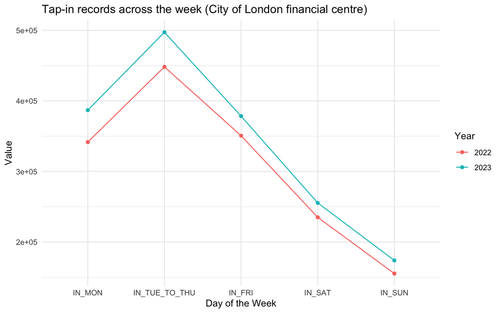

```r
summary_long <- summary_sqm %>%
  pivot_longer(cols = starts_with("IN_"),
               names_to = "day_of_week",
               values_to = "value") %>%
  mutate(day_of_week = factor(day_of_week,
                              levels = c("IN_MON", "IN_TUE_TO_THU", "IN_FRI", "IN_SAT", "IN_SUN")))

ggplot(summary_long, aes(x = day_of_week, y = value, color = factor(year), group = year)) +
  geom_line() +
  geom_point() +
  labs(title = "Tap-in records across the week (City of London financial centre)",
       x = "Day of the Week",
       y = "Value",
       color = "Year") +
  theme_minimal()
```

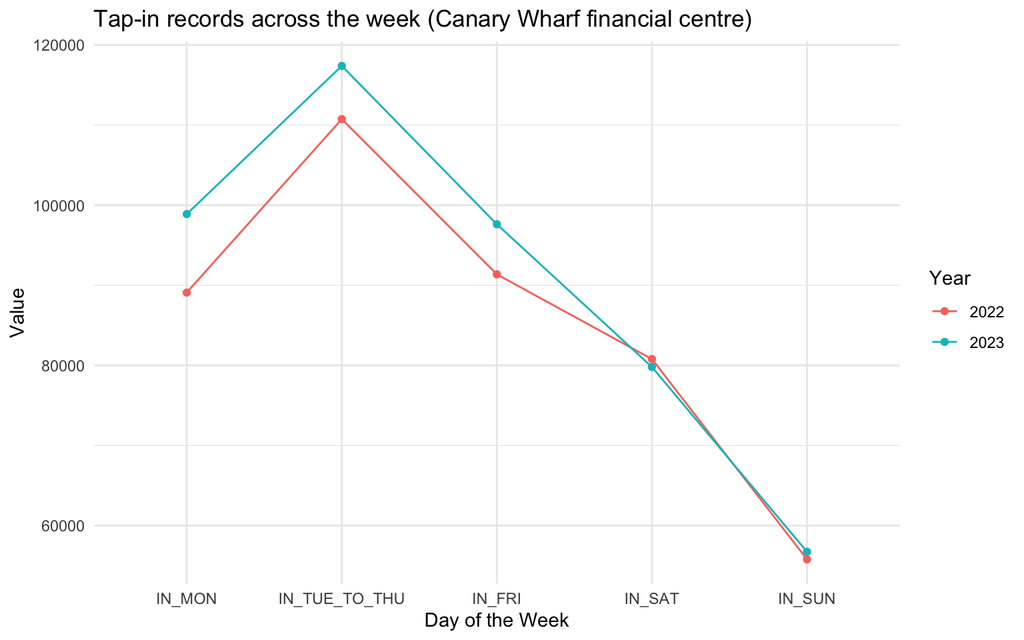

```r
summary_long <- summary_wharf %>%
  pivot_longer(cols = starts_with("IN_"),
               names_to = "day_of_week",
               values_to = "value") %>%
  mutate(day_of_week = factor(day_of_week,
                              levels = c("IN_MON", "IN_TUE_TO_THU", "IN_FRI", "IN_SAT", "IN_SUN")))

ggplot(summary_long, aes(x = day_of_week, y = value, color = factor(year), group = year)) +
  geom_line() +
  geom_point() +
  labs(title = "Tap-in records across the week (Canary Wharf financial centre)",
       x = "Day of the Week",
       y = "Value",
       color = "Year") +
  theme_minimal()
```

The general pattern seems to be stable across the two years, but let’s delve deeper into the weekdays.

```r
summary_sqm <- summary_sqm %>%
  mutate(
    mon_over_tt = (IN_MON / IN_TUE_TO_THU) - 1,
    fri_over_tt = (IN_FRI / IN_TUE_TO_THU) - 1
  )

summary_wharf <- summary_wharf %>%
  mutate(
    mon_over_tt = (IN_MON / IN_TUE_TO_THU) - 1,
    fri_over_tt = (IN_FRI / IN_TUE_TO_THU) - 1
  )
```

See if we can visualise it…

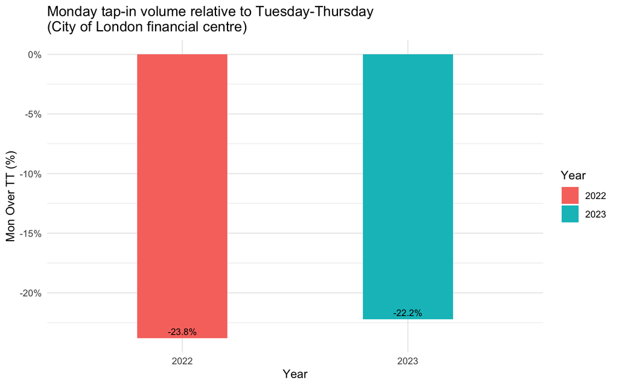

```r
plot_mon_sqm <-
  ggplot(summary_sqm, aes(x = factor(year), y = mon_over_tt * 100, fill = factor(year))) +
  geom_bar(stat = "identity", width = 0.4) +
  geom_text(aes(label = sprintf("%.1f%%", mon_over_tt * 100)),
            vjust = -0.5, color = "black", size = 3) +
  scale_y_continuous(labels = label_percent(scale = 1)) +
  labs(title = "Monday tap-in volume relative to Tuesday-Thursday \n(City of London financial centre)",
       x = "Year",
       y = "Mon Over TT (%)",
       fill = "Year") +
  theme_minimal()

plot_mon_sqm
```

Fridays:

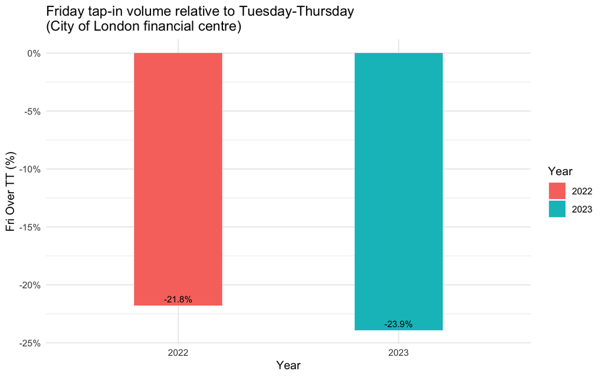

```r
plot_fri_sqm <-
ggplot(summary_sqm, aes(x = factor(year), y = fri_over_tt * 100, fill = factor(year))) +
  geom_bar(stat = "identity", width = 0.4) +  # Adjust width for narrower bars
  geom_text(aes(label = sprintf("%.1f%%", fri_over_tt * 100)),
            vjust = -0.5, color = "black", size = 3) +
  scale_y_continuous(labels = label_percent(scale = 1)) +
  labs(title = "Friday tap-in volume relative to Tuesday-Thursday \n(City of London financial centre)",
       x = "Year",
       y = "Fri Over TT (%)",
       fill = "Year") +
  theme_minimal()

plot_fri_sqm
```